# AKurtin SSF Homework

Anna Kurtin

2023-04-24

# SSF Homework

## Part 1: Data Preparation

To start, I’ll be reading in the wolf GPS data. It looks like summer has data on less packs, but I’m interested in examining the effects of the covariates I looked at in the RSF in the context of summer. I am interested to see what their habitat selection looks like when they aren’t as constrained by ice and snow.

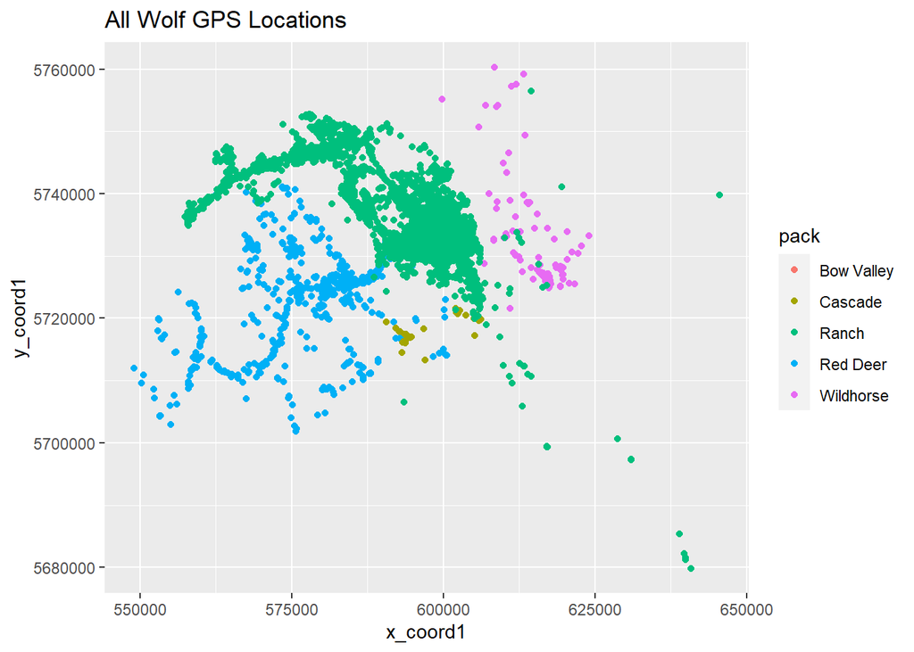

```r
wolfGPS <- read.csv("Data/wolf_data.csv")
# Take a look at what this GPS data looks like
ggplot(wolfGPS, aes(x_coord1, y_coord1, colour = pack)) +
  geom_point()+
  labs(title ="All Wolf GPS Locations")
```

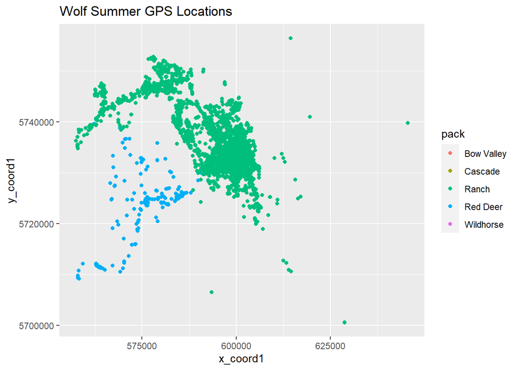

```r
# Pick a season:
wolf_summer <- wolfGPS %>% filter(season=="summer")
# unique(wolf_summer$wolfuid)
ggplot(wolf_summer, aes(x_coord1, y_coord1, colour = pack)) +
  geom_point() +
  labs(title ="Wolf Summer GPS Locations")
```

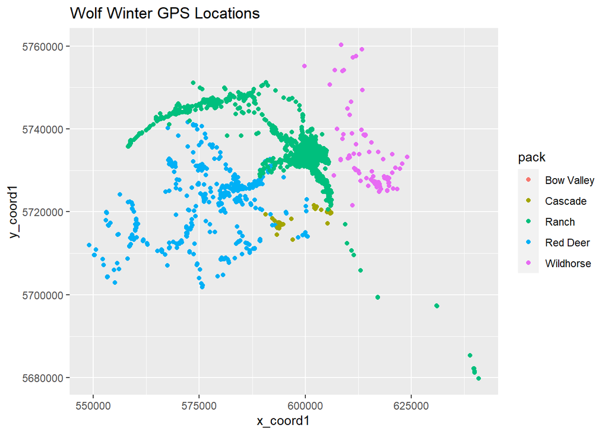

```r
# Summer only gives us ranch and red deer

wolf_winter <- wolfGPS %>% filter(season=="winter")
ggplot(wolf_winter, aes(x_coord1, y_coord1, colour = pack)) +
  geom_point() +
  labs(title ="Wolf Winter GPS Locations")
```

```r
# winter gives us more points
```

Next, I’ll clean up the data and create a shapefile from it.

```r
# convert wolf data into a shapefile
# Select out only columns that have a lat and long
wolf2<-wolf_summer[complete.cases(wolf_summer[10:11]),]

# Unite date and time into a column
wolf_summer2 <- wolf2 %>% unite(datetime,c(date,time),sep=" ")

# Reformat the date and time column into class datetime
wolf_summer2 <- wolf_summer2 %>% mutate(datetime_new=as.POSIXct(datetime,format="%m/%d/%y %H:%M"))

# remove the NAs in the datetime_new column
wolf_summer2<-wolf_summer2[complete.cases(wolf_summer2[24]),]
# Check to make sure there are no NA's
wolf_summer2 %>% filter(is.na(xcoord)==TRUE)
```

```
##  [1] v1           id1          id           wolfid       wolfuid
##  [6] pack         fixid        datetime     lat          long
## [11] altitude     fixtime      temp         fixstatus    fixtstatus2
## [16] n_sats       pdop         x_coord1     y_coord1     xcoord
## [21] ycoord       date_time    season       datetime_new
## <0 rows> (or 0-length row.names)
```

```r
wolf_summer2 %>% filter(is.na(ycoord)==TRUE)
```

```
##  [1] v1           id1          id           wolfid       wolfuid
##  [6] pack         fixid        datetime     lat          long
## [11] altitude     fixtime      temp         fixstatus    fixtstatus2
## [16] n_sats       pdop         x_coord1     y_coord1     xcoord
## [21] ycoord       date_time    season       datetime_new
## <0 rows> (or 0-length row.names)
```

```r
wolf_summer2 %>% filter(is.na(datetime_new)==TRUE)
```

```
##  [1] v1           id1          id           wolfid       wolfuid
##  [6] pack         fixid        datetime     lat          long
## [11] altitude     fixtime      temp         fixstatus    fixtstatus2
## [16] n_sats       pdop         x_coord1     y_coord1     xcoord
## [21] ycoord       date_time    season       datetime_new
## <0 rows> (or 0-length row.names)
```

```r
# for future plotting, make the wolf data into a shapefile
# define the lat long as epsg 4326
wolf_sf <- st_as_sf(wolf_summer2,
                      coords = c("long","lat"),
                      crs = "EPSG:4326")
```

Next, I’ll load in the spatial data. The two covariates I am interested in looking at in this analysis is conifer land cover and elevation.

```r
# pull the landcover data in from lab 3
lancov <- rast(".\\Data\\landcover16.tif")
# Check the crs for this raster
crs(lancov) # looks like it is in crs 26911, so let's change it to match our wolf shapefile
```

```
## [1] "PROJCRS[\"NAD83 / UTM zone 11N\",\n    BASEGEOGCRS[\"NAD83\",\n        DATUM[\"North American Datum 1983\",\n            ELLIPSOID[\"GRS 1980\",6378137,298.257222101,\n                LENGTHUNIT[\"metre\",1]]],\n        PRIMEM[\"Greenwich\",0,\n            ANGLEUNIT[\"degree\",0.017453292519…
```

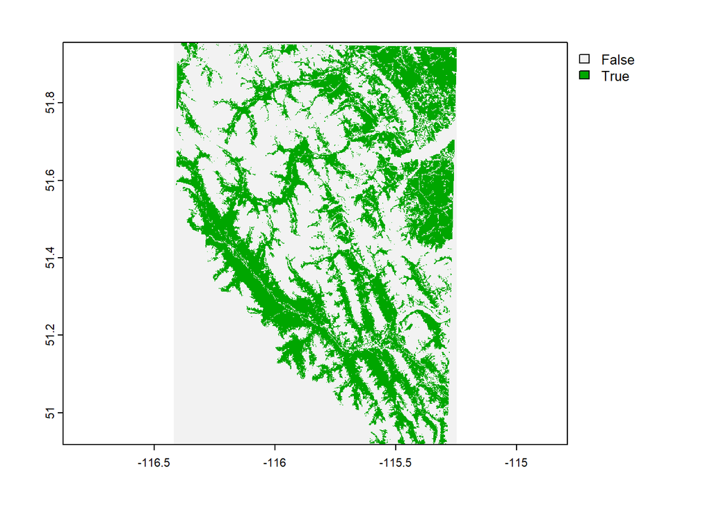

```r
# match the projection
lancov2 <- lancov %>% terra::project("EPSG:4326", method = "near")
# looking at conifer is 1,2, or 3
# select the levels of lancov that are 1,2, or 3
conif <- lancov2$HABITATTYPE %in% c("Open Conifer","Moderate Conifer","Closed Conifer")
plot(conif)
```

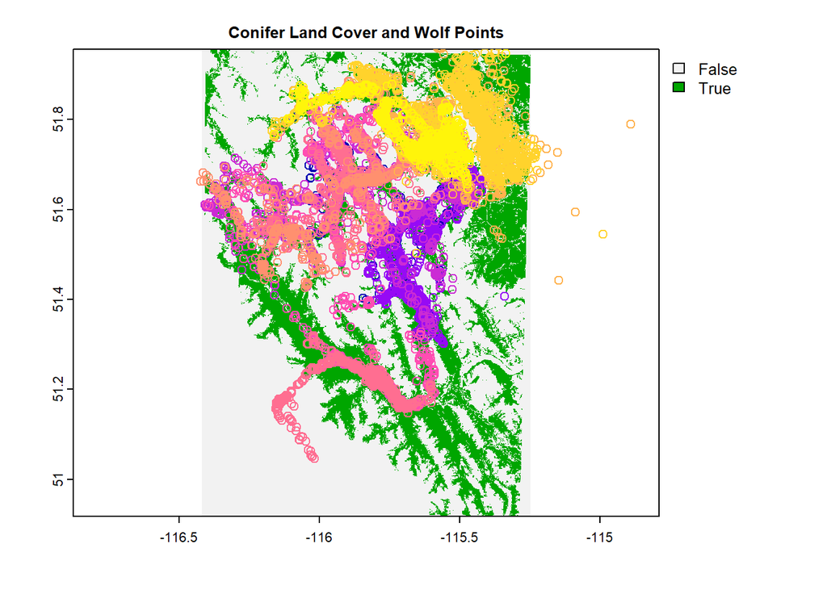

```r
#convert to a raster for future use
conif_r <- as(conif, "Raster")
# The name of this raster is undefined, so let's name it
names(conif_r) <- "conifer"

## Test how data looks
plot(conif, main = "Conifer Land Cover and Wolf Points")
plot(wolf_sf, add=TRUE) # two points are off here but overall it looks fine
```

```r
# Now let's pull in the elevation data
elevation <- rast(".\\Data\\Elevation2.tif")
# check the projection
crs(elevation) #26911
```

```
## [1] "PROJCRS[\"NAD83 / UTM zone 11N\",\n    BASEGEOGCRS[\"NAD83\",\n        DATUM[\"North American Datum 1983\",\n            ELLIPSOID[\"GRS 1980\",6378137,298.257222101,\n                LENGTHUNIT[\"metre\",1]]],\n        PRIMEM[\"Greenwich\",0,\n            ANGLEUNIT[\"degree\",0.017453292519…
```

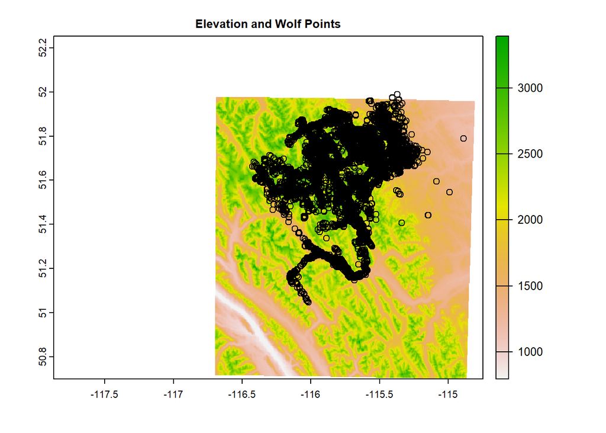

```r
# reproject to match the others
elev2 <- elevation %>% terra::project("EPSG:4326", method = "near")
# convert to a raster for future use
elev2_r <- as(elev2, "Raster")

## Test how data looks
plot(elev2, main = "Elevation and Wolf Points")
plot(wolf_sf$geometry, add=TRUE) # This looks good now
```

To fit my SSF, I need to take the wolf GPS points and make track data.

```r
# nest the data by the wolf ID
wolf_summer3 <- wolf_summer2 %>% nest(data = c(-wolfuid,-pack))

# Make the track data with a function
track_all <- wolf_summer3 %>%
 # make the track
 mutate(trk = map(data, function(d) {
   #transform from geographic to projected coord system
    amt::make_track(tbl=d, .x=long, .y=lat, .t=datetime_new, crs = 4326) %>% # changed from tbl=d, .x=xcoord, .y=ycoord, .t=datetime_new
      amt::transform_coords(st_crs(conif))}))


#summarize sampling rates by individuals and then unnest
samp_rates <- track_all %>% mutate(sr = lapply(trk, summarize_sampling_rate)) %>%
 dplyr::select(wolfuid, sr) %>% unnest(cols = c(sr))
samp_rates
```

```
## # A tibble: 12 × 10
##    wolfuid    min    q1 median  mean    q3   max     sd     n unit
##      <int>  <dbl> <dbl>  <dbl> <dbl> <dbl> <dbl>  <dbl> <int> <chr>
##  1      42  0.933  1.02   4     4.77  4.02 192    9.60    478 hour
##  2      45  1.97   2      2.02  3.50  4     40.0  3.16    583 hour
##  3      78  5.98   5.99   6     7.64  6.02  18    3.88     11 hour
##  4      85 13     15     15    44.6  31    721   57.0    4826 min
##  5      81  0.967  1      1     1.60  1.02  20.0  1.54   2711 hour
##  6      82  0.967  1      1     2.50  2    196    8.11   1739 hour
##  7      87  0.967  1      1     1.13  1.02  12    0.510  2435 hour
##  8      84  0.967  1      1.02  1.66  2     18.0  1.29   2595 hour
##  9      77  0.967  1      1     1.45  1.02  12.0  1.14   2801 hour
## 10      80  0.967  1      1     1.37  1.02  20    1.18   2842 hour
## 11      83  0.967  1      1     1.43  1.02  24    1.57   3073 hour
## 12      86 13     15     15    34.5  16    840   51.5    4170 min
```

Looking at the sampling rates, I see that the highest median fix rate is 6 hours, so I’ll be resampling them all to 6 hours.

Now, I’ll extract covariates to make an SSF dataframe.

```r
# Make an SSF dataframe
track_resamp_all <- track_all %>%
   mutate(steps = map(trk, function(x) {
     x %>% amt::track_resample(rate = minutes(360), tolerance = minutes(10)) %>% # resample the tracks for each individual
      amt::filter_min_n_burst() %>% # filter them into bursts
       amt::steps_by_burst() %>% amt::random_steps() %>% # filter them into bursts again
       amt::extract_covariates(covariates = elev2, where = "both") %>% # this does both start and end | names the column the same as the column and adds on where
       mutate(unique_step = paste(burst_,step_id_,sep="_")) %>%
#       mutate(elev_start = factor(Elevation2_start)) %>%
#       mutate(elev_end = factor(Elevation2_end)) %>% # filter them into bursts again
       amt::extract_covariates(covariates = conif, where = "both") %>% # this does both start and end | names the column the same as the column and adds on where
       mutate(conifer_start = factor(HABITATTYPE_start)) %>%
       mutate(conifer_end = factor(HABITATTYPE_end))
     }))

# Unnest this data
tracks_unnest <- track_resamp_all %>%
  dplyr::select(wolfuid,pack, steps) %>%
  unnest()

# Clean up the data
tracks_unnest <- tracks_unnest %>% rename(elev_start = Elevation2_start, elev_end = Elevation2_end) %>% select(-c(HABITATTYPE_start,HABITATTYPE_end))

# Make a column for pack as a factor
tracks_unnest <- tracks_unnest %>% mutate(pack_fac=factor(pack))
```

## Part 2: Statistical Analysis

First, let’s do some exploratory analyses of the effects of the covariates on step length to see if we need to include an interaction.

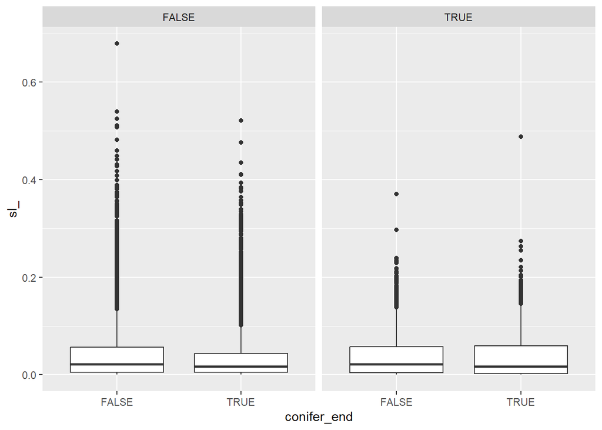

```r
# Look at step length and turning angle distributions
## sl_ for step length and ta_ for turning angle, time end is t2_

# for making plots:
tracks_plotting <- tracks_unnest %>% filter(is.na(conifer_end)==FALSE) %>% filter(is.na(elev_end)==FALSE)

# Relationship between step length and conifer land cover
# make a bar plot of sl_ for conifer_end = TRUE and FALSE
ggplot(data = tracks_plotting, mapping = aes(x = conifer_end, y = sl_)) +
  geom_boxplot() + facet_wrap(~case_)
```

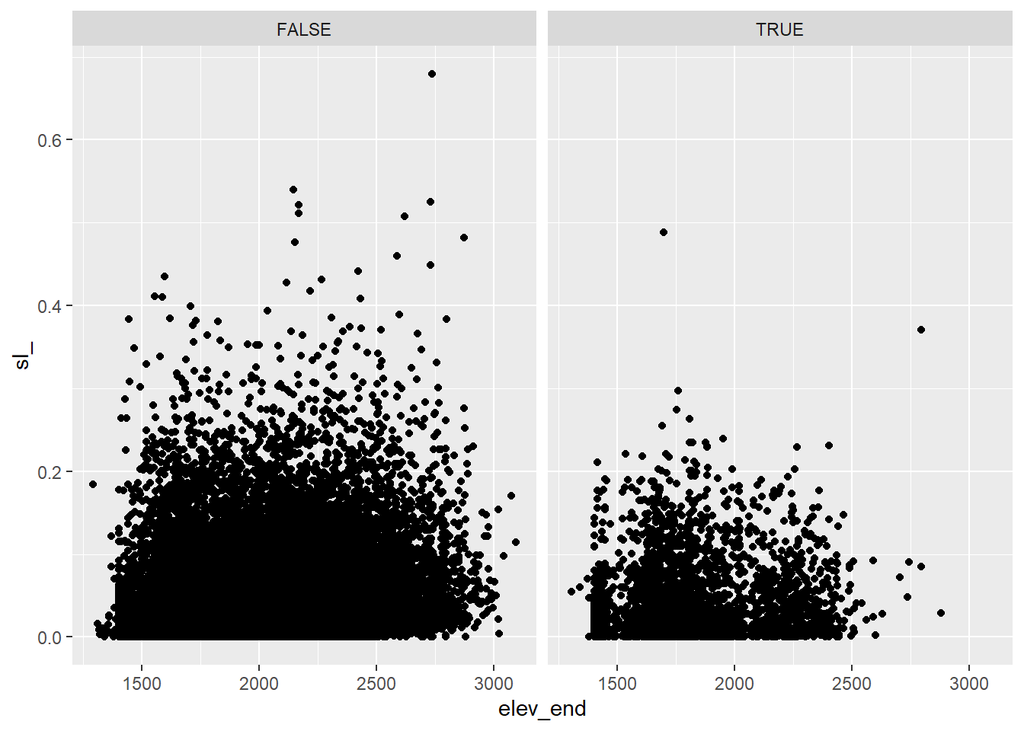

```r
# doesn't look like there's a difference

# Relationship between elevation and land cover
ggplot(data = tracks_plotting, mapping = aes(x = elev_end, y = sl_)) +
  geom_point()+ facet_wrap(~case_)
```

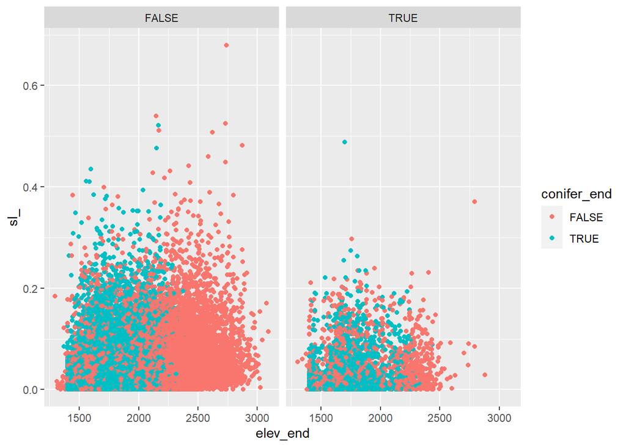

```r
# slight increase at the end but no clear trend

# Test for interactions with step length with covariates
ggplot(data = tracks_plotting, mapping = aes(x = elev_end, y = sl_, color = conifer_end)) +
  geom_point()+ facet_wrap(~case_)
```

We also don’t really see a trend here in the step length of our used points in relation to our covariates, so we don’t need to include an interaction. Now, let’s fit some models to our data.

**1. Naive GLM**

```r
# Fit a naive GLM
nGLM <- glm(case_~ I(conifer_end)+elev_end, data=tracks_unnest,family=binomial(link="logit"))
# Take a look at the exponentiated coefficients
coefs_nGLM <- exp(nGLM$coefficients)
```

**2. Step Selection Function**

```r
# Fit an SSF Model
# hypothesis that habitat selection varies as a function of conifer presence, elevation, and the interaction of the conifer and elevation
ssf_mod <- tracks_unnest %>% amt::fit_issf(case_ ~ conifer_end + elev_end + conifer_end:elev_end + strata(unique_step))
summary(ssf_mod)
```

```
## Call:
## coxph(formula = Surv(rep(1, 38104L), case_) ~ conifer_end + elev_end +
##     conifer_end:elev_end + strata(unique_step), data = data,
##     method = "exact")
##
##   n= 37679, number of events= 3449
##    (425 observations deleted due to missingness)
##
##                                coef  exp(coef)   se(coef)       z Pr(>|z|)
## conifer_endTRUE          -0.5708772  0.5650296  0.3127038  -1.826   0.0679 .
## elev_end                 -0.0030669  0.9969378  0.0001131 -27.126   <2e-16 ***
## conifer_endTRUE:elev_end  0.0001080  1.0001080  0.0001710   0.632   0.5276
## ---
## Signif. codes:  0 '***' 0.001 '**' 0.01 '*' 0.05 '.' 0.1 ' ' 1
##
##                          exp(coef) exp(-coef) lower .95 upper .95
## conifer_endTRUE             0.5650     1.7698    0.3061    1.0429
## elev_end                    0.9969     1.0031    0.9967    0.9972
## conifer_endTRUE:elev_end    1.0001     0.9999    0.9998    1.0004
##
## Concordance= 0.65  (se = 0.006 )
## Likelihood ratio test= 1037  on 3 df,   p=<2e-16
## Wald test            = 841.9  on 3 df,   p=<2e-16
## Score (logrank) test = 889  on 3 df,   p=<2e-16
```

```r
ssf_sum <- summary(ssf_mod$model)$coefficients

# Look at the outputs
ssf_sum
```

```
##                                   coef exp(coef)     se(coef)           z
## conifer_endTRUE          -0.5708771726 0.5650296 0.3127038060  -1.8256163
## elev_end                 -0.0030669129 0.9969378 0.0001130619 -27.1259677
## conifer_endTRUE:elev_end  0.0001080285 1.0001080 0.0001710176   0.6316804
##                               Pr(>|z|)
## conifer_endTRUE           6.790808e-02
## elev_end                 4.865098e-162
## conifer_endTRUE:elev_end  5.275957e-01
```

```r
AIC(ssf_mod)
```

```
## [1] 15955.07
```

**3. Clogit**

```r
# Fit a clogit model
clogit1 <- clogit(case_ ~ I(conifer_end) +(elev_end) + strata(unique_step),data = tracks_unnest)
#clogit1 <- clogit(case_ ~ I(landuseName=="Developed Open") + I(landuseName=="Developed Other") +I(landuseName=="Natural")+I(landuseName=="Crops") + strata(stratum), data = fisher6)
summary(clogit1)
```

```
## Call:
## coxph(formula = Surv(rep(1, 38104L), case_) ~ I(conifer_end) +
##     (elev_end) + strata(unique_step), data = tracks_unnest, method = "exact")
##
##   n= 37679, number of events= 3449
##    (425 observations deleted due to missingness)
##
##                         coef exp(coef)  se(coef)       z Pr(>|z|)
## I(conifer_end)TRUE -0.375042  0.687260  0.040122  -9.347   <2e-16 ***
## elev_end           -0.003042  0.996962  0.000106 -28.704   <2e-16 ***
## ---
## Signif. codes:  0 '***' 0.001 '**' 0.01 '*' 0.05 '.' 0.1 ' ' 1
##
##                    exp(coef) exp(-coef) lower .95 upper .95
## I(conifer_end)TRUE    0.6873      1.455    0.6353    0.7435
## elev_end              0.9970      1.003    0.9968    0.9972
##
## Concordance= 0.65  (se = 0.006 )
## Likelihood ratio test= 1037  on 2 df,   p=<2e-16
## Wald test            = 841.6  on 2 df,   p=<2e-16
## Score (logrank) test = 888.8  on 2 df,   p=<2e-16
```

```r
exp(coef(clogit1))
```

```
## I(conifer_end)TRUE           elev_end
##          0.6872601          0.9969622
```

```r
AIC(clogit1)
```

```
## [1] 15953.47
```

Here, we seee that there is little to no effect of elevation on selection and a negative effect of conifer land cover on selection.

**4. Coxme**

```r
# Create a time variable
tracks_unnest$time_ <- ifelse(tracks_unnest$case_ == 0, 2, 1)   #2 for control, 1 for case
# Fit a coxme model with random intercepts and random slopes
clogitM1<- coxme(Surv(time_,case_) ~ conifer_end + elev_end + conifer_end:elev_end  + (1|pack_fac) + (0+pack_fac) , data=tracks_unnest)
AIC(clogitM1)
```

```
## [1] 71594.97
```

```r
summary(clogitM1)
```

```
## Cox mixed-effects model fit by maximum likelihood
##   Data: tracks_unnest
##   events, n = 3449, 37679 (425 observations deleted due to missingness)
##   Iterations= 11 56
##                     NULL Integrated    Fitted
## Log-likelihood -36178.77  -35790.49 -35790.48
##
##                    Chisq df p    AIC    BIC
## Integrated loglik 776.56  8 0 760.56 711.40
##  Penalized loglik 776.57  7 0 762.57 719.55
##
## Model:  Surv(time_, case_) ~ conifer_end + elev_end + conifer_end:elev_end +      (1 | pack_fac) + (0 + pack_fac)
## Fixed coefficients
##                                   coef exp(coef)     se(coef)      z       p
## conifer_endTRUE          -3.801363e-01 0.6837682 2.829182e-01  -1.34 1.8e-01
## elev_end                 -2.090382e-03 0.9979118 8.755493e-05 -23.88 0.0e+00
## pack_facCascade           6.870366e-01 1.9878161 7.521015e-02   9.13 0.0e+00
## pack_facRanch             4.894802e-01 1.6314679 6.496018e-02   7.54 4.9e-14
## pack_facRed Deer          8.599090e-01 2.3629456 7.108416e-02  12.10 0.0e+00
## pack_facWildhorse         2.068568e-01 1.2298064 7.345568e-02   2.82 4.9e-03
## conifer_endTRUE:elev_end  5.867858e-05 1.0000587 1.558056e-04   0.38 7.1e-01
##
## Random effects
##  Group    Variable  Std Dev      Variance
##  pack_fac Intercept 1.348113e-03 1.817409e-06
```

**5. iSSF with glmmTMB**

```r
# Fit glmmTMB model with random effect of step ID and random slope of pack on conifer
TMBm1 <- glmmTMB(case_~ I(conifer_end) + elev_end + (1|step_id_) + (0 + I(conifer_end)|pack_fac), family = poisson, data = tracks_unnest, doFit = FALSE)

TMBm1$parameters$theta[1] <-log(1e3) # set theta one (the 0 in the 0 + I(landuse_end)|id)
TMBm1$mapArg <-list(theta=factor(c(NA, 1:3)))
glmm.TMB.random <- glmmTMB::fitTMB(TMBm1) # fit your model (from above) using these arguments
summary(glmm.TMB.random)
```

```
##  Family: poisson  ( log )
## Formula:
## case_ ~ I(conifer_end) + elev_end + (1 | step_id_) + (0 + I(conifer_end) |
##     pack_fac)
## Data: tracks_unnest
##
##      AIC      BIC   logLik deviance df.resid
##  30639.5  30690.8 -15313.8  30627.5    37673
##
## Random effects:
##
## Conditional model:
##  Groups   Name                Variance  Std.Dev.  Corr
##  step_id_ (Intercept)         1.000e+06 1000.0000
##  pack_fac I(conifer_end)FALSE 1.695e-01    0.4117
##           I(conifer_end)TRUE  1.066e-01    0.3265 0.95
## Number of obs: 37679, groups:  step_id_, 511; pack_fac, 5
##
## Conditional model:
##                      Estimate Std. Error z value Pr(>|z|)
## (Intercept)         1.074e-02  4.424e+01   0.000  0.99981
## I(conifer_end)TRUE -2.592e-01  7.618e-02  -3.402  0.00067 ***
## elev_end           -2.157e-03  8.446e-05 -25.535  < 2e-16 ***
## ---
## Signif. codes:  0 '***' 0.001 '**' 0.01 '*' 0.05 '.' 0.1 ' ' 1
```

```r
# Look at the coefficients
coefTMB <- fixef(glmm.TMB.random)
```

Here, we see that elevation has little to no effect on selection and conifer land cover has a negative effect on selection.

# Part 3: Inference